# Numerické proměnné a míry centrality

## Typy proměnných - opakování

- nominální
- ordinální
- kardinální (metrické, numerické, kvantitativní)
  - intervalové
  - poměrové
- numerické diskrétní
- numerické spojité

## Empirická distribuce dat

Tvar dat

## Moudrost davu: počet fazolek ve sklenici

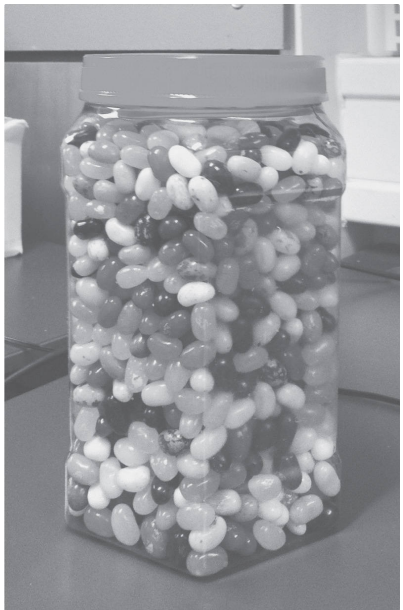

Zdroj: Spiegelhalter (2019)

## Jak vizualizovat mnoho dat?

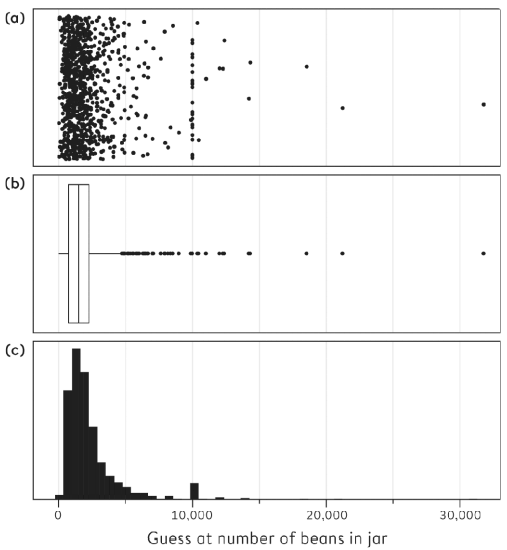

Zdroj (Spiegelhalter 2019)

## Míry centrality

## Míry centrality (measures of central tendency)

Míry centrality se také nazývají míry polohy (measures of the location of the data distribution).

- (aritmetický) průměr - suma dělená počtem případů
- medián - prostřední hodnota z řady seřazené podle velikosti
- modus - nejčastější hodnota

## Aritmetický průměr z dat (sample mean)

\[\bar{x} = (x_1 + x_2 + … +x_n)/n\]

kde \(x_1, x_2, …, x_n\) jsou jednotlivá pozorování a \(n\) je počet těchto pozorování.

Zkrácený zápis:

\[\bar{x} = \frac{1}{n} \sum_{i=1}^n x_i \]

## Průměr a princip páky

Průměr reprezentuje data v určitém smyslu, ale nemusí být reprezentativní v jiném smyslu.

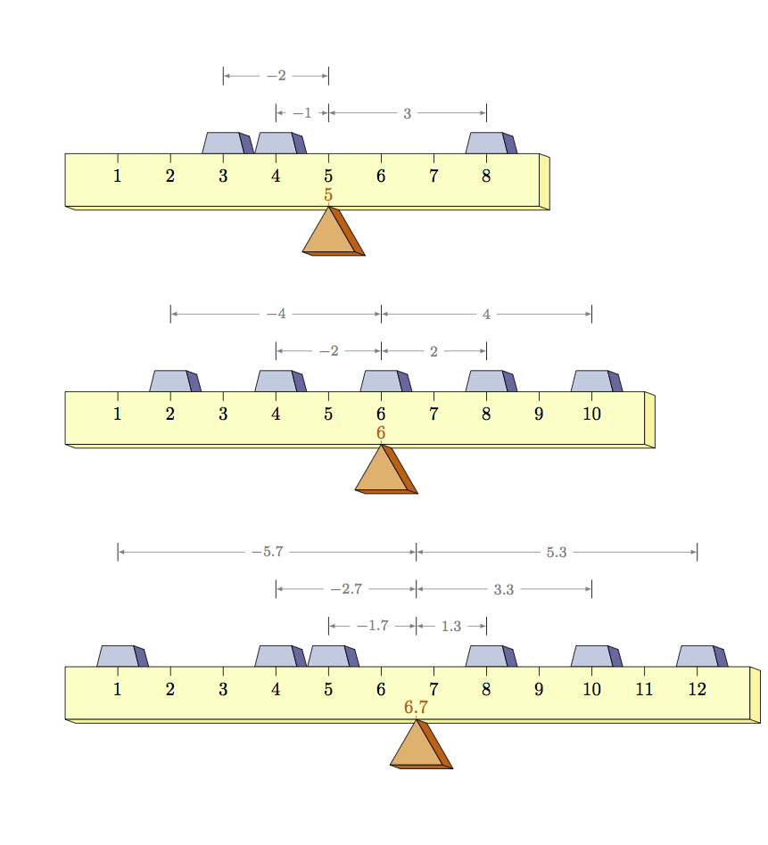

Obrázek z [brilliant.org](https://brilliant.org/wiki/arithmetic-mean/)

## Už jsme viděli: Jak se šíří COVID

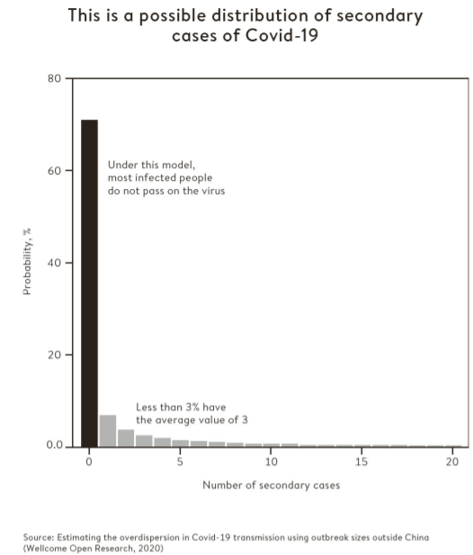

Převzato z Spiegelhalter and Masters (2021)

## Šikmost (Skewness)

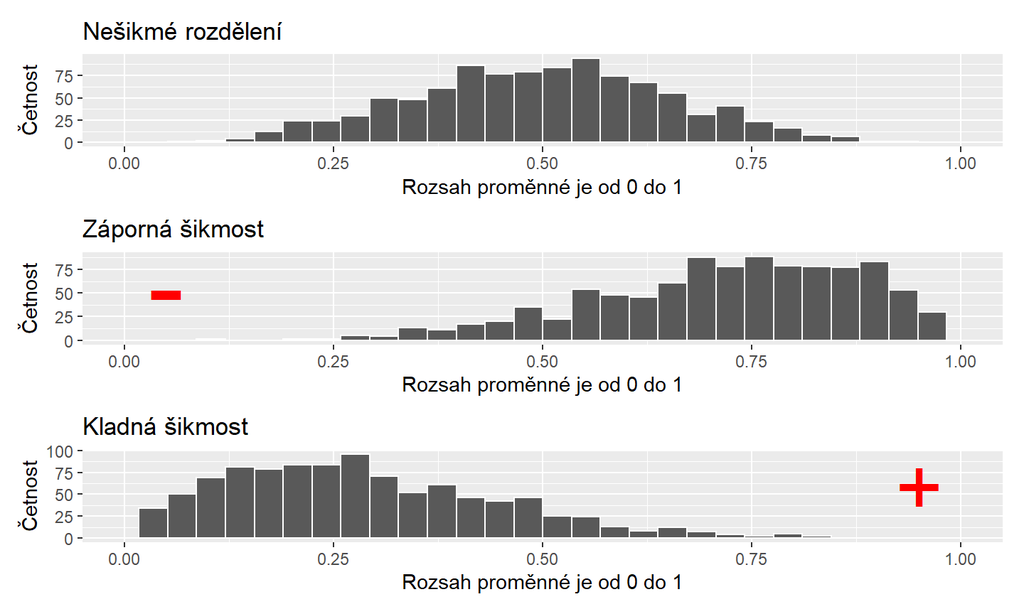

- Ve kterém ze tří obrázků výše bude průměr větší/menší než medián? Kdy bude stejný?

## Měli bychom tedy raději používat medián?

Studie Evropské centrální banky v roce 2013: německá mediánová domácnost je výrazně chudší než domácnosti středomořských zemí.

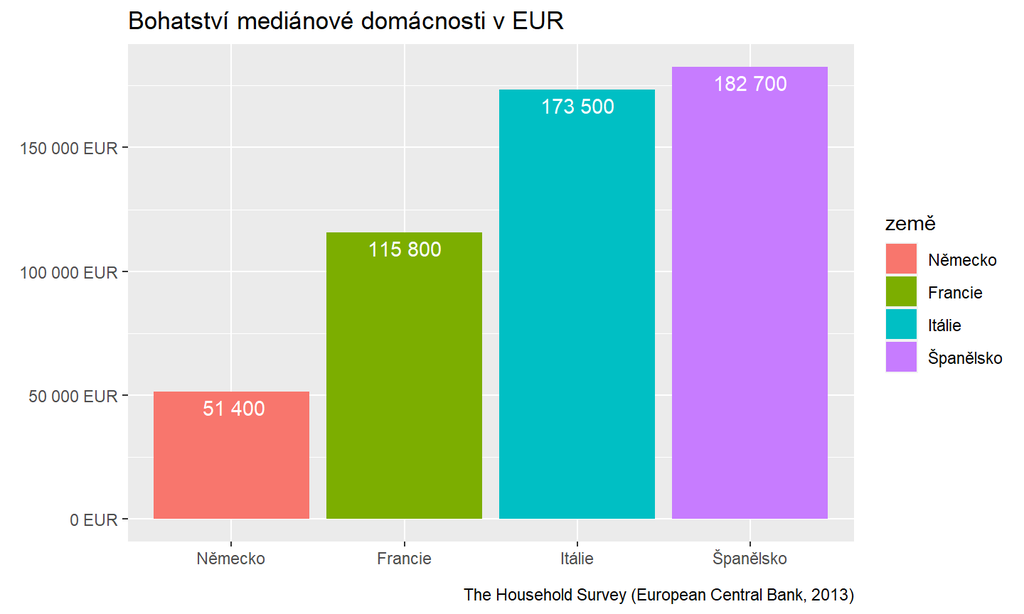

Zdroj dat je [článek na voxeu.org](https://voxeu.org/article/are-germans-poorer-other-europeans-principal-eurozone-differences-wealth-and-income#fn)

## Mediánová vs. průměrná domácnost

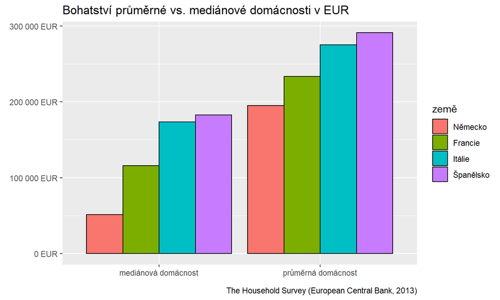

## Zohlednění velikosti domácností

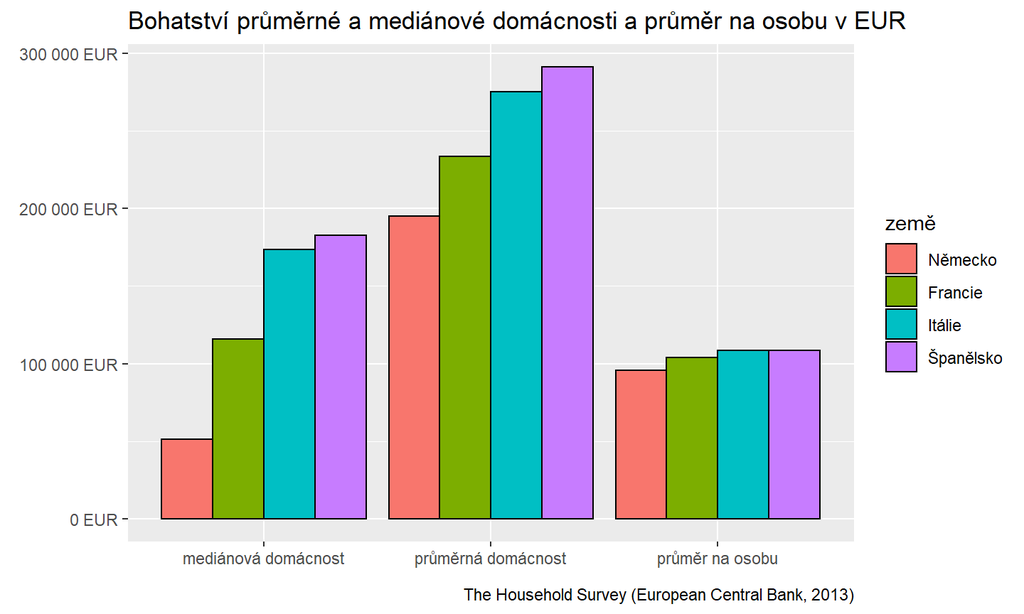

## Kvantily: Kvartily, kvintily, decily, percentily

## Kvartily

- Analogické k mediánu, dělí seřazená data na čtyři stejné části.
- Kolik je kvartilů?
- Jaký je vztah mezi mediánem a 2. kvartilem?
- Existuje více způsobů výpočtu kvartilů, nelamte si tím hlavu

## Kvintily

- … na 5 stejných částí

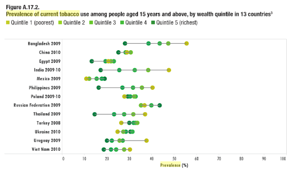

[Obrázek převzat z statisticshowto.com](https://www.statisticshowto.com/quintile-definition/) s odvoláním na World Health Organization.

## Decily

- … na 10 stejných částí

## Percentily

- … na 100 stejných částí. Kvantily jsou zpravidla na percentily převoditelné.

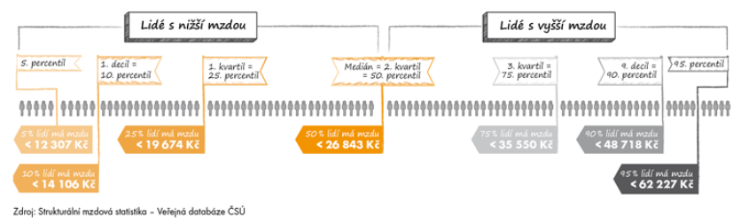

[Zdroj Statistika a My](https://www.statistikaamy.cz/o-slozitem-jednoduse/rozvetvena-rodina-kvantilu/)

## Logaritmické měřítko

## Jak vizualizovat mnoho dat?

### Původní měřítko

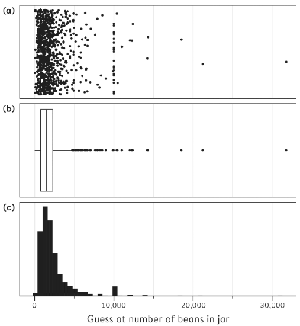

Zdroj (Spiegelhalter 2019)

### Logaritmické měřítko

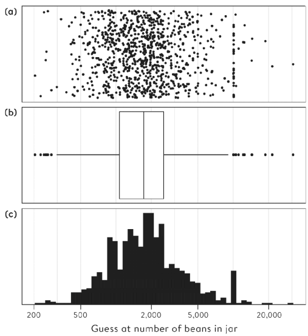

## Logaritmus

Logaritmus: vyjadřuje, jakým číslem musíme umocnit daný základ, abychom dostali požadovaný výsledek.

\[log_28 = 3 \]

\[log_{10}100 = 2 \]

Ve statistice využívám zpravidla logaritmické měřítko při základu 10 pro zobrazování, tento logaritmus převádí čísla na jejich řády. Umožňuje společně vizualizovat velké a malé hodnoty (srazí je k sobě).

## Příklad: savci a jejich mozky

| species | body_wt | brain_wt |
| --- | --- | --- |
| Africanelephant | 6654.000 | 5712.0 |
| Africangiantpouchedrat | 1.000 | 6.6 |
| ArcticFox | 3.385 | 44.5 |
| Arcticgroundsquirrel | 0.920 | 5.7 |
| Asianelephant | 2547.000 | 4603.0 |
| Baboon | 10.550 | 179.5 |
| Bigbrownbat | 0.023 | 0.3 |
| Braziliantapir | 160.000 | 169.0 |
| Cat | 3.300 | 25.6 |
| Chimpanzee | 52.160 | 440.0 |

Inspirováno [tutorialem Marvina Lemose](https://rstudio-pubs-static.s3.amazonaws.com/433476_9ce6707ae2794d96923b7258703fdff7.html)

## Distribuce hmotností těl a mozků

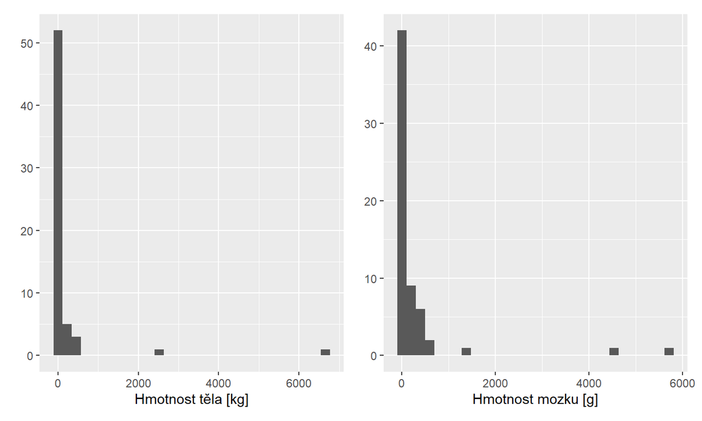

## Vztah mezi hmotností těl a mozků

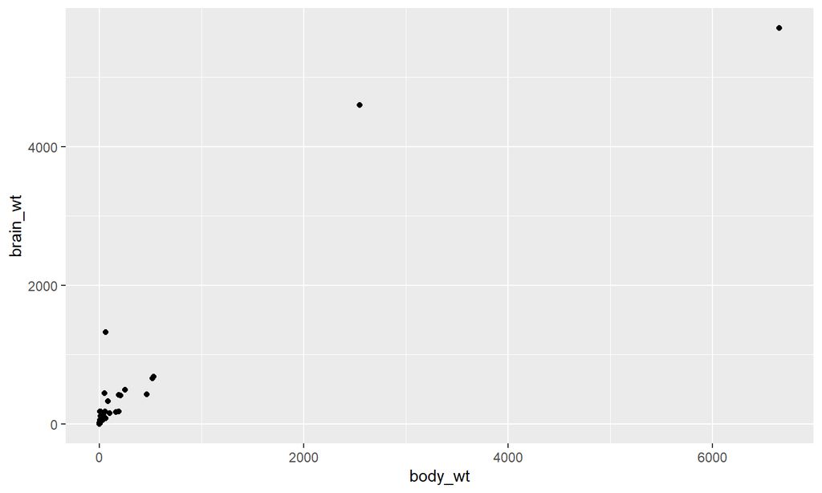

## Vztah na logaritmickém měřítku

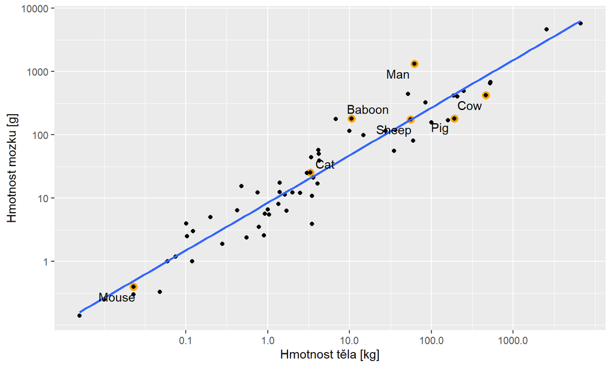

## U logaritmického měřítka je častý vědecký zápis

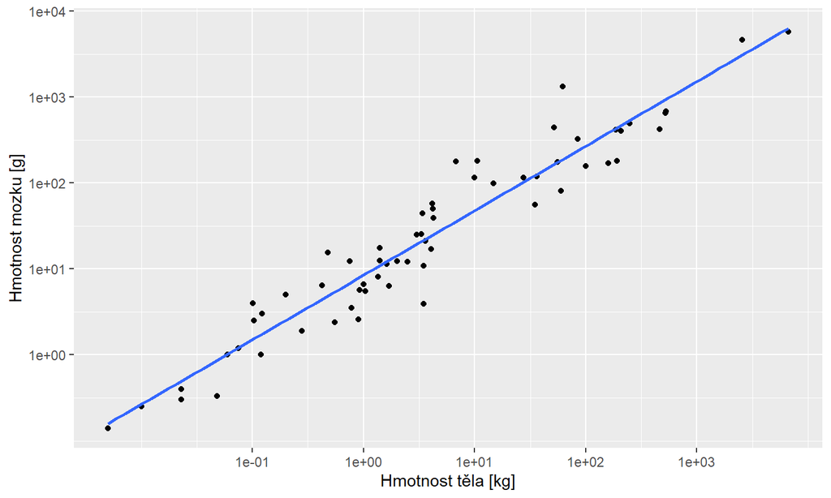

## Robustní statistiky

## Co je robustní statistika?

- Ukazetel, který není (příliš) ovlivněn extrémními hodnotami (odlehlými pozorováními).

## Průměr vs. medián (odstraněna jediná hodnota)

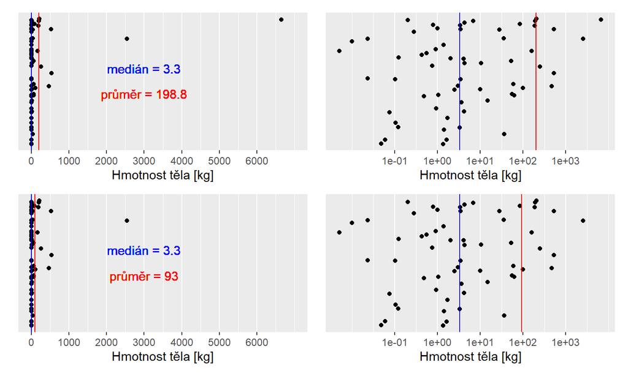

## Oříznutý průměr

- Medián potlačuje šikmost distribuce i extrémní případy, oříznutý průměr potlačuje především extrémní případy.
- Oříznutý průměr (trimmed mean, truncated mean): průměr z hodnot po “oříznutí” určitého procenta extrémních (nejmenší a největších hodnot).
- NADSTAVBA: Windsorized mean - podobný jako oříznutý, místo odříznutí ale hodnoty nahradí nejvyšší/nejnižší ještě neodstraněnou hodnotou.

## Jiné průměry

## Jiné průměry

- vážený průměr
- klouzavý průměr
- geometrický průměr (nadstavba)
- harmonický průměr (nadstavba)

## Vážený průměr

\[\bar{x} = \frac{\sum_{i=1}^n x_i*w_i}{\sum_{i=1}^n w_i} \]

kde \(w_i\) jsou váhy jednotlivých pozorování

## Vážený průměr - příklad

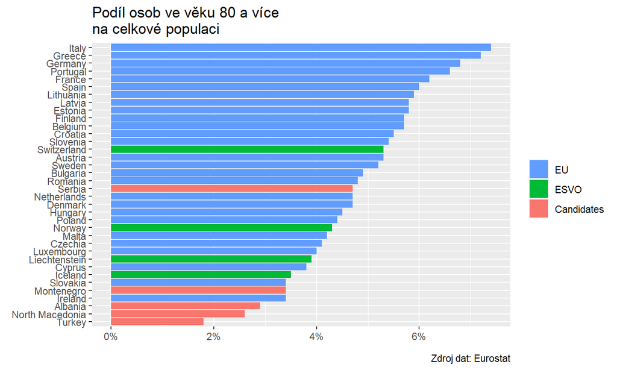

Jak vypočítat podíl osob ve věku 80 a více v rámci EU?

## Příklad Itálie, Česko a Slovensko

- Podíl 80 a více ČR = 4,1 %
- Podíl 80 a více IT = 7,4 %
- Podíl 80 a více SK = 3,4 %
- Počet obyvatel ČR = 10 700 000
- Počet obyvatel IT = 59 600 000
- Počet obyvatel SK = 5 500 000
- Aritmetický průměr = \((4.1 + 7.4 + 3.4) / 3 = 4.97\)
- Vážený průměr = \((4.1*10.7 + 7.4*59.6 + 3.4*5.5) / (10.7 + 59.6 + 5.5) = 6.64\)

## Klouzavý průměr

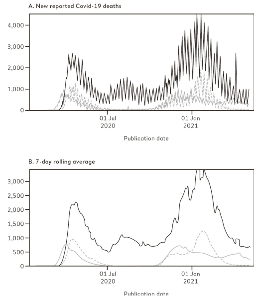

Spiegelhalter and Masters (2021)

- Tmavá plná čára = USA
- Světlá plná čára = IT
- Světlá prerušovaná čára = UK

## Nadstavba

## Geometrický průměr (nadstavba)

Pokud je růst HDP ve třech po sobě jdoucích letech 2 %, 20 % a 38 %, průměrný růst HDP je tedy 20 % (aritmetický průměr). Problém je, že pokud by byl třikrát po sobě narostlo HDP o 20 %, dospěli bychom k jinému výslednému HDP. Geometrický průměr je číslo, o které by každý rok muselo narůst HDP, abychom dospěli ke stejnému výsledku, jako když reálný růst byl 2, 20 a 38 %.

Jak se vyvíjelo HDP: \(100*1.02*1.20*1.38 = 168.9\)

Aritmetický průměr: \(100*1.2*1.2*1.2 = 172.8\)

## Výpočet geometrického průměru (nadstavba)

\[\bar{x}_G = \sqrt[n]{x_1*x_2*x_3 ... x_n} \] kde \({x_1*x_2*x_3 ... x_n}\) vyjadřují tempo růstu ve formátu, kdy 2 % jsou vyjádřena jako 1,02

Tedy v našem případě: \(\sqrt[3]{1.02*1.20*1.38} = 1.191\)

A lze snadno ověřit, že: \(100*1.191*1.191*1.191 = 168.9\)

## Harmonický průměr (nadstavba)

\[\bar{x}_H = \frac{n}{\sum_{i=1}^n \frac{1}{x_i}} \]

Linka A vyrobí produkt za 30 minut, linka B za 10 minut. Jak dlouho průměrně trvá vyrobit jeden výrobek? 20 minut je špatná odpověď, protože by vedla k predikci, že za hodinu vyrobím v průměru 3 výrobky na jedné lince, tedy 6 na obou dohromady. Ale ve skutečnosti vyrobím za hodinu 8 výrobků.

Výpočet pomocí harmonického průměru je: \(2/(1/30 + 1/10) = 15\)

Tedy průměrně na jedné lince výrobek za 15 minut, 4 za hodinu a celkem 8 výrobků za hodinu.

## Logaritmické měřítko a exponenciální růst

- Co je to exponenciální růst?
- Exponenciální růst - něco se “x-násobí” za určitou časovou jednotku (zdvojnásobí, zdesetinásobí, ale i jen vynásobí 1.001)

## Jak vypadá exponenciální růst?

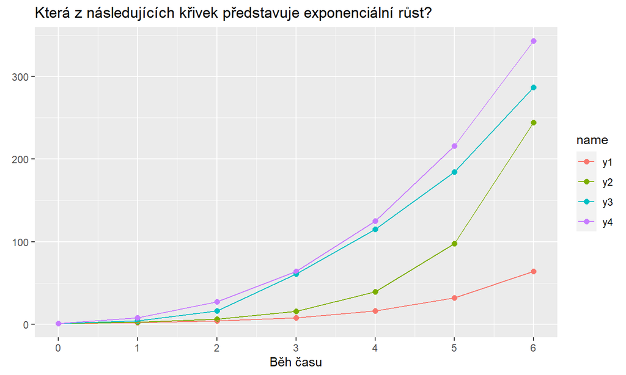

## Zlogaritmování pomáhá rozpoznat exponenciální růst

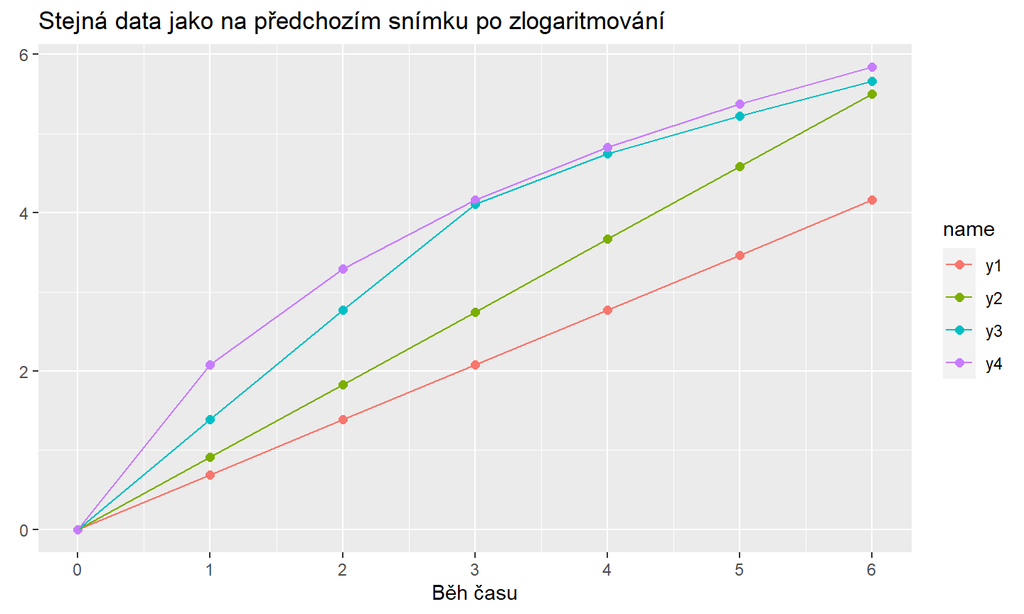

## Reference v prezentaci

Následuje seznam referencí, které v prezentaci neměly aktivní proklik na zdroj.

Spiegelhalter, David. 2019. *The Art of Statistics: Learning from Data*. UK USA Canada Ireland Australia India New Zealand South Africa: Pelican.

Spiegelhalter, David, and Anthony Masters. 2021. *Covid by Numbers: Making Sense of the Pandemic with Data*. Pelican.